# Furniture as a Reflection of Values: Understanding customers' priorities in buying furniture to discover opportunity areas for Amazon's furniture line

**Figure 10. Latent Semantic Analysis for category drawer.**

Drawer

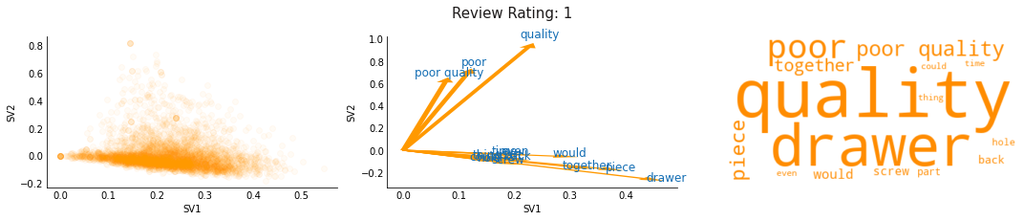

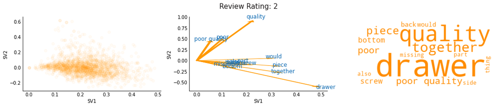

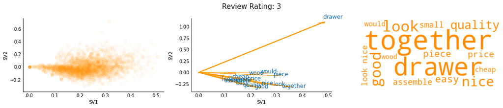

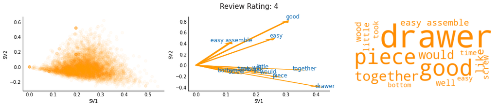

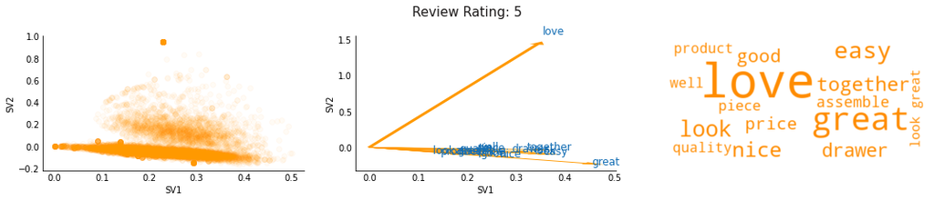

```python
display(HTML('''<center style="font-size:12px;font-style:default;"><b>
Figure 10. Latent Semantic Analysis for category drawer.
</b></center>'''))


cat = 'drawer'
display(HTML(f'''<h3 style="text-align:center">
                {cat.title()}
                </h3>'''))
for idx in range(1, 6):
    x = lsa[cat][idx]['X_new']
    p = lsa[cat][idx]['p']
    feat_names = bow_ng_all[cat][idx]
    title = f'Review Rating: {idx}'
    plot_lsa(x, p, feat_names, title)
```

For **Drawer**, we can see for low ratings we got words such as `hole`, `missing`, and `poor quality`. It seems like these are the customers who were not able to receive the items in the quality expected. For high ratings, the words we were able to extract were `price`, `quality`, and `easy assemble` similar to the previous categories.

**Figure 11. Latent Semantic Analysis for category mattress.**

Mattress

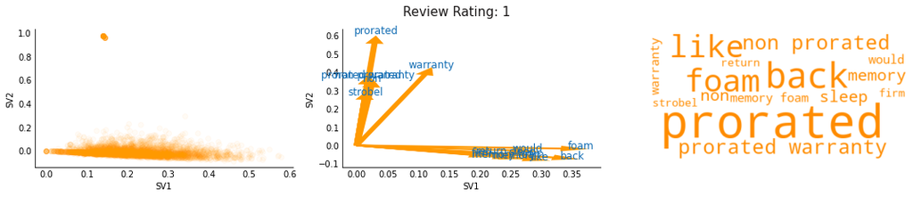

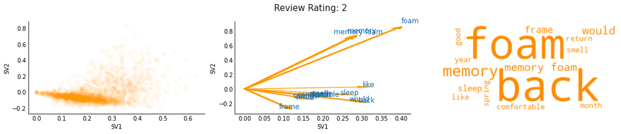

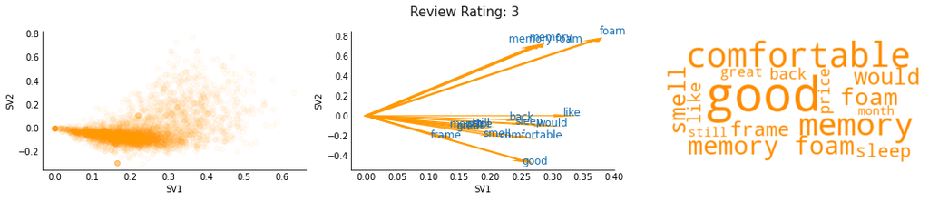

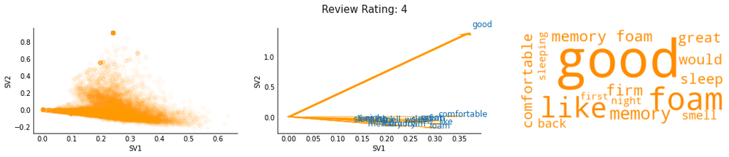

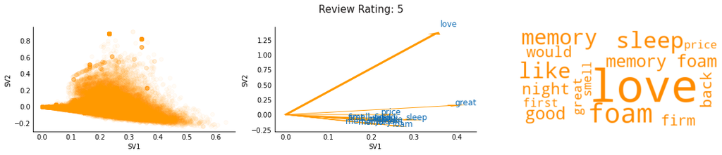

```python
display(HTML('''<center style="font-size:12px;font-style:default;"><b>
Figure 11. Latent Semantic Analysis for category mattress.
</b></center>'''))


cat = 'mattress'
display(HTML(f'''<h3 style="text-align:center">
                {cat.title()}
                </h3>'''))
for idx in range(1, 6):
    x = lsa[cat][idx]['X_new']
    p = lsa[cat][idx]['p']
    feat_names = bow_ng_all[cat][idx]
    title = f'Review Rating: {idx}'
    plot_lsa(x, p, feat_names, title)
```

For **Mattress**, we can see for low ratings we got words such as `warranty`, `prorated`, and `prorated warranty`. It seems that the customers are having troubles with regards to the warranty of their mattress which Amazon could take a look into. For high ratings, the words we were able to extract were `memory foam`, `memory`, `sleep`, `firm`, `smell` meaning the customers appreciate mattresses that smell good and have memory foam.

## VI. Conclusion

Amazon continues to dominate the online retailing scene as reported by several reputable media institutions such as CNBC and Forbes. This is highly attributable to their large and loyal customer base as reflected in their consistently high overall average customer ratings from 2002 to 2015 (scope of this study).  
When we studied these customer ratings for the furniture line items through time, we observed the presence of seasonality, prominent in the earlier years. This could imply that either they still had not fully understood the priorities of their customers when it comes to buying furniture or customers were still not used to how online shopping for furniture works. In the latter years, however, we saw how Amazon was able to steadily increase the ratings until they reached a level where they were constantly high. This denotes that Amazon was finally able to understand the preferences of their customers when buying furniture and that the customers have become savvy with doing online purchases even for relatively expensive items such as furniture.  
Using word cloud visualizations, we tried to identify the common priorities that customers have when purchasing the four furniture item categories we decided to limit the scope of this study to. It seemed that for the furniture line as a whole, customers valued easy assembly of item and comfortability the most. Looking at the individual categories, further insights were derived in terms of customer preferences. For desks, it seems that types that come with drawers are preferred. For mattresses, the customers value a good mix of memory foam quality and spring quality to get a good night's sleep. For sofas, concepts of cushion, price, and color are given importance. And finally, for drawers, sturdiness along with the quality and aesthetic of wood material used seem to be favored.  
We then proceeded with plotting the cumulative explained variance to visually see the number of components needed to explain at least 90% of the original data. From the visualizations, we deduced that there could be fewer clusters or words that are more similar to each other within the 5 rating. We also found out that the number of components within category ranges small compared to the difference with other categories that could mean that there are different complexities between categories that could be a factor of the number of samples for that category  
After which, we plotted the top 15 words that have L2 norm with largest weights between first two singular vectors (SVs) for each category and rating. From here, we were able to conclude that the reason most people rate their product low is when they have delivered poor quality or damaged items. On the other hand, items that were comfortable, easy to assemble, and sturdy seems to drive the high ratings.  
**Across all categories, there seemed to be the common insight that customers highly value comfortability, ease of assembly, and perceived quality of the item as compared to the price paid when purchasing furniture items from Amazon.** Taking a step further, we give emphasis on customers’ priorities for the mattress category as 1) it seems to be one of Amazon’s top selling items in the furniture line and 2) we derived highly weighted words that appeared only in this category. We note that the low ratings for this category had customer feedback highlighting the concept of `prorated warranty`.  
*"With a prorated warranty:*

You pay a certain percentage to have your mattress repaired or replaced

The percentage generally goes up over the period of a predetermined number of years

The older the mattress gets, the more easily it becomes damaged, so your percentage of repair and/or replacement costs goes up" $^3$

The implication of this is that some customers may not be happy with how Amazon calculates the percentage they will pay for repairs or replacements of mattresses. Additionally, some may also not be satisfied with how Amazon qualifies whether defects or damages will be covered at all by the limited warranty or not.

## VII. Recommendations

Having concluded that customers favor comfortability, ease of assembly, and perceived quality of the item as compared to the price paid when purchasing furniture items from Amazon, we recommend that Amazon focus on these aspects when evaluating furniture items they sell to help retain and possibly expand their customer base.  
Amazon is currently enjoying a large proportion of 4-5-star ratings in feedback. However, a single negative review can have a big impact on a business despite its multiple positive feedback. Hence, they also need to look into their warranty policy and understand what exactly is turning customers off.  
This report was limited to customer feedback on four categories of Amazon's furniture line generated from 2002 to 2015. For further studies, we recommend that feedback from more recent years (2016 to present) be included to add more relevance to the insights as the e-commerce scene is fast-changing. We would also suggest that the study be expanded to include other furniture categories.  
As mentioned in the introduction part of this report, Amazon started to create in-house brands of top-selling items. In 2019, they created two private-label furniture brands, Rivet (mid-century modern) and Stone & Beam (farmhouse chic). These brands aim to create stylish furniture items that would be accessible and affordable for customers.$^4$ We then believe that it would be a good idea to see how these two brands are doing compared to the other furniture brands carried by Amazon.  
This report only focused on US sales. A comparative analysis on sales to Western regions versus sales to Asian regions may also be a good angle to take on a further study. It could give rise to interesting insights about differing or similar consumer behavior when it comes to purchasing furniture online.

## References

[1] Thomas, L. (2021) "As e-commerce sales proliferate, Amazon holds on to top online retail spot". https://www.cnbc.com/2021/06/18/as-e-commerce-sales-proliferate-amazon-holds-on-to-top-online-retail-spot.html

[2] Kim, E. (2017) "As Amazon’s dominance grows, suppliers are forced to play by its rules". https://www.cnbc.com/2017/12/21/as-amazons-dominance-grows-suppliers-are-forced-to-play-by-its-rules.html

[3] "Understanding mattress warranties". https://mattresshelp.org/mattress-warranties/

[4] Kaplan, S. (2021) "We tested Amazon's affordable mid-century and farmhouse chic furniture and the pieces are surprisingly comparable to CB2 and West Elm". https://www.businessinsider.com/amazon-furniture-rivet-stone-and-beam-review